# MBL tissues RNAseq clustering (top 4 and bottom 4 MYC-expressing samples)

# Introduction

This notebook focuses on the analysis of RNA sequencing data from Medulloblastoma tissue samples. The goal is to identify differentially expressed genes and perform clustering based on MYC expression levels. The notebook involves loading necessary libraries, data preprocessing, running DESeq2 analysis, PCA visualization, identifying cluster-defining genes, and creating heatmaps.

# 1. Setup and Libraries

First, we load the required libraries for the analysis: stringr, tidyverse, DESeq2, RColorBrewer, fgsea, msigdb, ExperimentHub, GSEABase, org.Hs.eg.db, AnnotationDbi, and egg.

# 2. Load and pre-process Data

## 2.1. Load and pre-process RNA-seq counts

```r
# Load RNAseq counts table
canonical_RNA_counts_all <- read.table("/hpc/pmc_vanheesch/projects/Damon/Medulloblastoma_ORFs/Medulloblastoma_analyses_final/rnaseq_regular/data/processed/featurecounts/medullo_allsamples.counts", check.names = F)

# Fix sample column names
colnames(canonical_RNA_counts_all) <- sapply(basename(colnames(canonical_RNA_counts_all)),
                                             function(x)
                                               gsub(".Aligned.sortedByCoord.out.bam", "", x))

# Remove unnecessary metadata columns
canonical_RNA_counts_all <- canonical_RNA_counts_all %>%
  dplyr::select(6:ncol(.))

# Write to .csv
# write.csv(canonical_RNA_counts_all, "/hpc/pmc_vanheesch/projects/Damon/Medulloblastoma_ORFs/Medulloblastoma_analyses_final/rnaseq_regular/results/tables/S1_RNA_fulllength_canonical_counts.csv", quote = F)
```

## 2.2. Load and process metadata

```r
# Load metadata
sample_metadata <- readxl::read_xlsx("/hpc/pmc_vanheesch/projects/Damon/Medulloblastoma_ORFs/Medulloblastoma_analyses_final/rebuttal_analyses/01.26.2023_Table_S1_reworked.xlsx", sheet = 1, col_names = T, skip = 2, .name_repair = "universal")
# Filter samples with both RNAseq and riboseq data
sample_metadata_complete <- sample_metadata[which(
  !is.na(sample_metadata$RNASeq_file_names) &
    !is.na(sample_metadata$RiboSeq_file_names..final.)), ]

# Extract RNA sample names based on filenames
sample_metadata_complete <- sample_metadata_complete %>%
  mutate(rna_name = gsub("_R1.*", "", gsub(";.*", "", .$RNASeq_file_names)))

# Select metadata for cell line samples
# sample_metadata_complete$MYC.group <- as.factor(sample_metadata_complete$MYC.group)

sample_metadata_complete[which(sample_metadata_complete$Molecular.subgroup == "Group 4"), ]$Molecular.subgroup = "G4"
sample_metadata_complete[which(sample_metadata_complete$Molecular.subgroup == "Group 3"), ]$Molecular.subgroup = "G3"

sample_metadata_complete$Molecular.subgroup <- as.factor(sample_metadata_complete$Molecular.subgroup)

rownames(sample_metadata_complete) <- sample_metadata_complete$Sample_ID
```

## 2.3. Match RNA-seq counts and metadata

```r
# Match RNA-seq counts columns to metadata rows
match_counts <- unique(str_extract(sample_metadata_complete$RNASeq_file_names, str_c(colnames(canonical_RNA_counts_all), collapse = "|")))
canonical_RNA_counts <- canonical_RNA_counts_all[, match_counts]

# Find matching metadata
metadata_matches <- grep(paste(match_counts, collapse = "|"), sample_metadata_complete$RNASeq_file_names)
sample_metadata_complete <- sample_metadata_complete[metadata_matches, ]
colnames(canonical_RNA_counts) <- sample_metadata_complete$Sample_ID
```

# 3. Differential expression analysis

## 3.1. Run DESeq2 to select top and bottom MYC expressing samples

```r
# Run DESeq2
dds <- DESeqDataSetFromMatrix(countData = canonical_RNA_counts, colData = sample_metadata_complete, design = ~ MYC_status)
dds <- DESeq(dds)
```

```
-- replacing outliers and refitting for 2167 genes
-- DESeq argument 'minReplicatesForReplace' = 7
-- original counts are preserved in counts(dds)
```

```r
mat_dds <- counts(dds, normalized = T)

# Transform DESeq2 output
vsd <- vst(dds, blind = F)

# Store dds counts and vsd counts in matrices
mat_vsd <- assay(vsd)
MYC_vsd <- mat_vsd["ENSG00000136997", ]
```

```r
# Select MYC expression values
MYC_dds <- mat_dds["ENSG00000136997", ]
MYC_dds_df <- data.frame("Sample_ID" = names(MYC_dds),
                         MYC_lvl = MYC_dds)

# Sort the dataframe based on MYC expression
MYC_dds_df <- MYC_dds_df[order(MYC_dds_df$MYC_lvl), ]

# Add MYC expression to metadata
sample_metadata_complete <- left_join(sample_metadata_complete, MYC_dds_df)
```

[figure not shown]

```r
# Generate the colors
set1_colors <- brewer.pal(n = length(unique(sample_metadata_complete$Sample_Type)), name = "Set1")
set2_colors <- brewer.pal(n = length(unique(sample_metadata_complete$MYC_status)), name = "Set2")

# Create the color mapping for the labels
label_colors <- setNames(set1_colors, sort(unique(sample_metadata_complete$Sample_Type)))
label_colors_ordered <- label_colors[sample_metadata_complete$Sample_Type]
label_colors_ordered <- label_colors_ordered[order(sample_metadata_complete$MYC_lvl, decreasing = TRUE)]

# Create the fill mapping for the bars
fill_colors <- setNames(set2_colors, sort(unique(sample_metadata_complete$MYC_status)))

# Create a vector of new labels
new_labels <- c("Unknown" = "Unknown", "MYC_amp" = "MYC Amplified", "not_amp" = "Not Amplified", "MYC_gain" = "MYC Gain")


ggplot(sample_metadata_complete, aes(y = MYC_lvl, x = reorder(Sample_ID, -MYC_lvl), fill = MYC_status)) +
  geom_bar(stat = "identity") +
  geom_text(aes(label = "",
                y = -Inf),
            size = 0) +
  geom_point(aes(y = -Inf,
                 color = Sample_Type),
             size = 0) +
  scale_color_manual(name = "Sample Type",
                     values = label_colors,
                     guide = guide_legend(override.aes = list(size = 4))) +
  scale_fill_manual(name = "MYC status",
                    values = fill_colors,
                    labels = new_labels) +
  scale_y_continuous(expand = expansion(mult = c(0, 0.1))) +

  theme_classic() +
  labs(x = "Sample", y = "Norm. MYC RNA-seq counts", title = "Primary tissues and cell lines with matching Ribo-seq data") +
  theme(axis.text.x = element_text(angle = 90, vjust = 0.5, hjust = 1, color = label_colors_ordered))
ggsave(filename = "/hpc/pmc_vanheesch/projects/Damon/Medulloblastoma_ORFs/Medulloblastoma_analyses_final/rebuttal_analyses/tissue_analyses/plots/MYC_lvl_tissues_cell_lines.pdf", width = unit(7, "inch"), height=unit(5, "inch"))
```

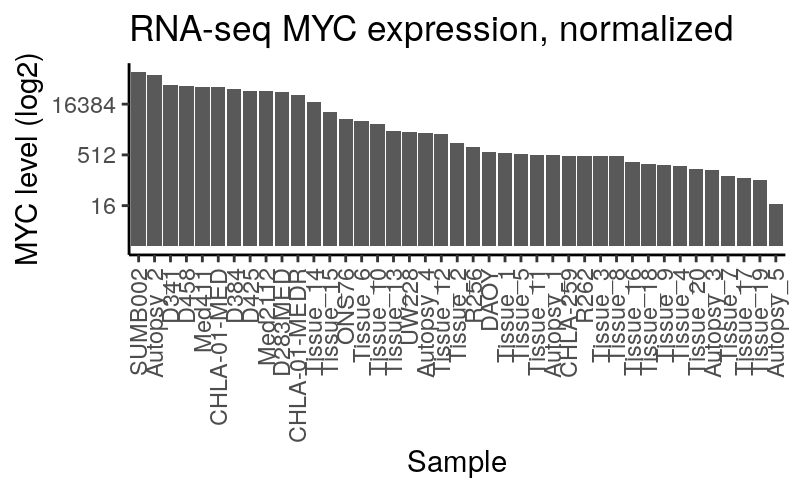

```r
ggplot(sample_metadata_complete, aes(y = MYC_lvl, x = reorder(Sample_ID, -MYC_lvl), fill = )) +
  geom_bar(stat = "identity") +
  scale_y_continuous(trans = "log2") +
  theme_classic() +
  labs(x = "Sample", y = "MYC level (log2)", title = "RNA-seq MYC expression, normalized") +
  theme(axis.text.x = element_text(angle = 90, vjust = 0.5, hjust = 1))
```